# Risk Factor Analysis

## Outcome Variable

**Outcome Variable:** pers_wast

## Predictor Variables

**Intervention Variable:** feducyrs

**Adjustment Set:**

- arm
- W_mage
- meducyrs
- W_mhtcm
- W_mwtkg
- W_mbmi
- W_gagebrth
- W_birthwt
- W_birthlen
- single
- delta_W_mage
- delta_meducyrs
- delta_W_mhtcm
- delta_W_mwtkg
- delta_W_mbmi
- delta_W_gagebrth
- delta_W_birthwt
- delta_W_birthlen
- delta_single

## Stratifying Variables

The analysis was stratified on these variable(s):

- agecat
- studyid
- country

## Data Summary

| agecat | studyid | country | feducyrs | pers_wast | n_cell | n |
| --- | --- | --- | --- | --- | --- | --- |
| 0-24 months | COHORTS | GUATEMALA | High | 0 | 182 | 999 |
| 0-24 months | COHORTS | GUATEMALA | High | 1 | 6 | 999 |
| 0-24 months | COHORTS | GUATEMALA | Low | 0 | 431 | 999 |
| 0-24 months | COHORTS | GUATEMALA | Low | 1 | 14 | 999 |
| 0-24 months | COHORTS | GUATEMALA | Medium | 0 | 351 | 999 |
| 0-24 months | COHORTS | GUATEMALA | Medium | 1 | 15 | 999 |
| 0-24 months | COHORTS | INDIA | High | 0 | 454 | 1242 |
| 0-24 months | COHORTS | INDIA | High | 1 | 33 | 1242 |
| 0-24 months | COHORTS | INDIA | Low | 0 | 366 | 1242 |
| 0-24 months | COHORTS | INDIA | Low | 1 | 38 | 1242 |
| 0-24 months | COHORTS | INDIA | Medium | 0 | 324 | 1242 |
| 0-24 months | COHORTS | INDIA | Medium | 1 | 27 | 1242 |
| 0-24 months | COHORTS | PHILIPPINES | High | 0 | 892 | 2659 |
| 0-24 months | COHORTS | PHILIPPINES | High | 1 | 31 | 2659 |
| 0-24 months | COHORTS | PHILIPPINES | Low | 0 | 736 | 2659 |
| 0-24 months | COHORTS | PHILIPPINES | Low | 1 | 44 | 2659 |
| 0-24 months | COHORTS | PHILIPPINES | Medium | 0 | 897 | 2659 |
| 0-24 months | COHORTS | PHILIPPINES | Medium | 1 | 59 | 2659 |
| 0-24 months | GMS-Nepal | NEPAL | High | 0 | 126 | 596 |
| 0-24 months | GMS-Nepal | NEPAL | High | 1 | 20 | 596 |
| 0-24 months | GMS-Nepal | NEPAL | Low | 0 | 221 | 596 |
| 0-24 months | GMS-Nepal | NEPAL | Low | 1 | 36 | 596 |
| 0-24 months | GMS-Nepal | NEPAL | Medium | 0 | 169 | 596 |
| 0-24 months | GMS-Nepal | NEPAL | Medium | 1 | 24 | 596 |
| 0-24 months | JiVitA-3 | BANGLADESH | High | 0 | 3853 | 15189 |
| 0-24 months | JiVitA-3 | BANGLADESH | High | 1 | 178 | 15189 |
| 0-24 months | JiVitA-3 | BANGLADESH | Low | 0 | 5568 | 15189 |
| 0-24 months | JiVitA-3 | BANGLADESH | Low | 1 | 367 | 15189 |
| 0-24 months | JiVitA-3 | BANGLADESH | Medium | 0 | 4914 | 15189 |
| 0-24 months | JiVitA-3 | BANGLADESH | Medium | 1 | 309 | 15189 |

[output cut: 90 more lines]

The following strata were considered:

- agecat: 0-24 months, studyid: COHORTS, country: GUATEMALA
- agecat: 0-24 months, studyid: COHORTS, country: INDIA
- agecat: 0-24 months, studyid: COHORTS, country: PHILIPPINES
- agecat: 0-24 months, studyid: GMS-Nepal, country: NEPAL
- agecat: 0-24 months, studyid: JiVitA-3, country: BANGLADESH
- agecat: 0-24 months, studyid: JiVitA-4, country: BANGLADESH
- agecat: 0-24 months, studyid: LCNI-5, country: MALAWI
- agecat: 0-24 months, studyid: MAL-ED, country: BANGLADESH
- agecat: 0-24 months, studyid: MAL-ED, country: INDIA
- agecat: 0-24 months, studyid: MAL-ED, country: NEPAL
- agecat: 0-24 months, studyid: MAL-ED, country: PERU
- agecat: 0-24 months, studyid: MAL-ED, country: SOUTH AFRICA
- agecat: 0-24 months, studyid: MAL-ED, country: TANZANIA, UNITED REPUBLIC OF
- agecat: 0-24 months, studyid: NIH-Crypto, country: BANGLADESH
- agecat: 0-24 months, studyid: PROBIT, country: BELARUS
- agecat: 0-24 months, studyid: PROVIDE, country: BANGLADESH
- agecat: 0-24 months, studyid: SAS-CompFeed, country: INDIA
- agecat: 0-24 months, studyid: SAS-FoodSuppl, country: INDIA
- agecat: 0-24 months, studyid: TanzaniaChild2, country: TANZANIA, UNITED REPUBLIC OF
- agecat: 0-24 months, studyid: ZVITAMBO, country: ZIMBABWE

### Dropped Strata

Some strata were dropped due to rare outcomes:

- agecat: 0-24 months, studyid: LCNI-5, country: MALAWI
- agecat: 0-24 months, studyid: MAL-ED, country: BANGLADESH
- agecat: 0-24 months, studyid: MAL-ED, country: INDIA
- agecat: 0-24 months, studyid: MAL-ED, country: NEPAL
- agecat: 0-24 months, studyid: MAL-ED, country: PERU
- agecat: 0-24 months, studyid: MAL-ED, country: SOUTH AFRICA
- agecat: 0-24 months, studyid: MAL-ED, country: TANZANIA, UNITED REPUBLIC OF
- agecat: 0-24 months, studyid: NIH-Crypto, country: BANGLADESH
- agecat: 0-24 months, studyid: PROVIDE, country: BANGLADESH

## Methods Detail

We're interested in the causal parameters $E[Y_a]$ for all values of $a \in \mathcal{A}$. These parameters represent the mean outcome if, possibly contrary to fact, we intervened to set all units to have $A=a$. Under the randomization and positivity assumptions, these are identified by the statistical parameters $\psi_a=E_W[E_{Y|A,W}(Y|A=a,W)]$. In addition, we're interested in the mean of $Y$, $E[Y]$ under no intervention (the observed mean). We will estimate these parameters by using SuperLearner to fit the relevant likelihood factors -- $E_{Y|A,W}(Y|A=a,W)$ and $p(A=a|W)$, and then updating our likelihood fit using a joint TMLE.

For unadjusted analyses ($W=\{\}$), initial likelihoods were estimated using Lrnr_glm to estimate the simple $E(Y|A)$ and Lrnr_mean to estimate $p(A)$. For adjusted analyses, a small library containing Lrnr_glmnet, Lrnr_xgboost, and Lrnr_mean was used.

Having estimated these parameters, we will then use the delta method to estimate relative risks and attributable risks relative to a prespecified baseline level of $A$.

# Results Detail

## Results Plots

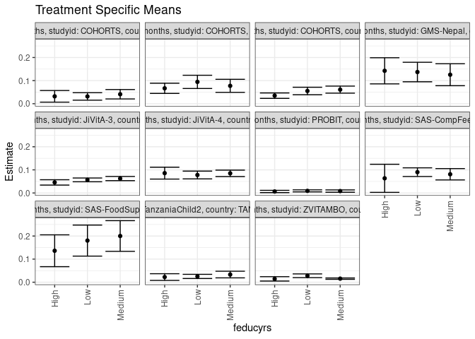

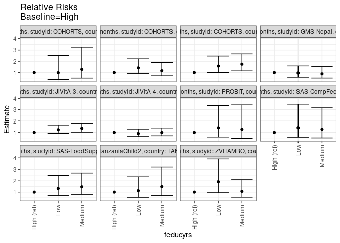

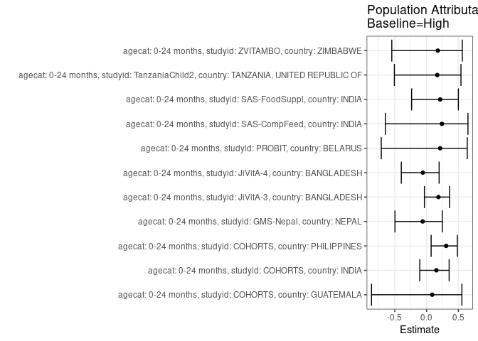

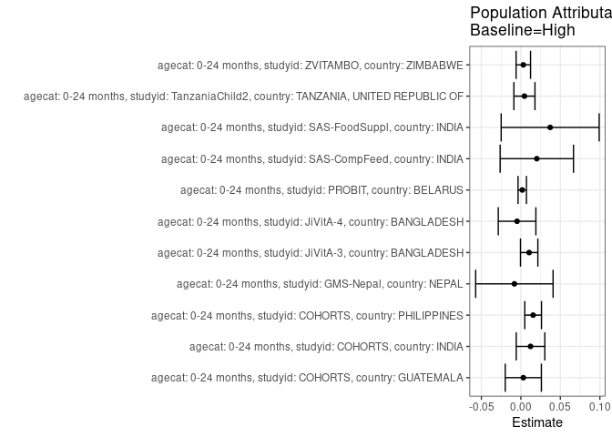

## Results Table

### Parameter: TSM

| agecat | studyid | country | intervention_level | baseline_level | estimate | ci_lower | ci_upper |
| --- | --- | --- | --- | --- | --- | --- | --- |
| 0-24 months | COHORTS | GUATEMALA | High | NA | 0.0319149 | 0.0067764 | 0.0570534 |
| 0-24 months | COHORTS | GUATEMALA | Low | NA | 0.0314607 | 0.0152340 | 0.0476873 |
| 0-24 months | COHORTS | GUATEMALA | Medium | NA | 0.0409836 | 0.0206627 | 0.0613045 |
| 0-24 months | COHORTS | INDIA | High | NA | 0.0666771 | 0.0445453 | 0.0888089 |
| 0-24 months | COHORTS | INDIA | Low | NA | 0.0944448 | 0.0657783 | 0.1231113 |
| 0-24 months | COHORTS | INDIA | Medium | NA | 0.0773238 | 0.0491137 | 0.1055339 |
| 0-24 months | COHORTS | PHILIPPINES | High | NA | 0.0348668 | 0.0231471 | 0.0465865 |
| 0-24 months | COHORTS | PHILIPPINES | Low | NA | 0.0550639 | 0.0388577 | 0.0712701 |
| 0-24 months | COHORTS | PHILIPPINES | Medium | NA | 0.0609315 | 0.0456383 | 0.0762247 |
| 0-24 months | GMS-Nepal | NEPAL | High | NA | 0.1424297 | 0.0858724 | 0.1989869 |
| 0-24 months | GMS-Nepal | NEPAL | Low | NA | 0.1371428 | 0.0949093 | 0.1793762 |
| 0-24 months | GMS-Nepal | NEPAL | Medium | NA | 0.1255385 | 0.0779897 | 0.1730874 |
| 0-24 months | JiVitA-3 | BANGLADESH | High | NA | 0.0457074 | 0.0341215 | 0.0572934 |
| 0-24 months | JiVitA-3 | BANGLADESH | Low | NA | 0.0566220 | 0.0484443 | 0.0647997 |
| 0-24 months | JiVitA-3 | BANGLADESH | Medium | NA | 0.0623832 | 0.0532784 | 0.0714880 |
| 0-24 months | JiVitA-4 | BANGLADESH | High | NA | 0.0858486 | 0.0601460 | 0.1115512 |
| 0-24 months | JiVitA-4 | BANGLADESH | Low | NA | 0.0777633 | 0.0609173 | 0.0946094 |
| 0-24 months | JiVitA-4 | BANGLADESH | Medium | NA | 0.0849865 | 0.0710250 | 0.0989480 |
| 0-24 months | PROBIT | BELARUS | High | NA | 0.0064316 | 0.0014647 | 0.0113985 |
| 0-24 months | PROBIT | BELARUS | Low | NA | 0.0090873 | 0.0046878 | 0.0134868 |
| 0-24 months | PROBIT | BELARUS | Medium | NA | 0.0081903 | 0.0031104 | 0.0132702 |
| 0-24 months | SAS-CompFeed | INDIA | High | NA | 0.0634408 | 0.0026712 | 0.1242103 |
| 0-24 months | SAS-CompFeed | INDIA | Low | NA | 0.0900586 | 0.0713513 | 0.1087659 |
| 0-24 months | SAS-CompFeed | INDIA | Medium | NA | 0.0810126 | 0.0564133 | 0.1056119 |
| 0-24 months | SAS-FoodSuppl | INDIA | High | NA | 0.1362158 | 0.0672897 | 0.2051419 |
| 0-24 months | SAS-FoodSuppl | INDIA | Low | NA | 0.1802951 | 0.1130987 | 0.2474916 |
| 0-24 months | SAS-FoodSuppl | INDIA | Medium | NA | 0.2000799 | 0.1335644 | 0.2665954 |
| 0-24 months | TanzaniaChild2 | TANZANIA, UNITED REPUBLIC OF | High | NA | 0.0223881 | 0.0079228 | 0.0368534 |
| 0-24 months | TanzaniaChild2 | TANZANIA, UNITED REPUBLIC OF | Low | NA | 0.0251736 | 0.0161255 | 0.0342217 |
| 0-24 months | TanzaniaChild2 | TANZANIA, UNITED REPUBLIC OF | Medium | NA | 0.0332779 | 0.0189349 | 0.0476209 |
| 0-24 months | ZVITAMBO | ZIMBABWE | High | NA | 0.0145161 | 0.0051010 | 0.0239312 |
| 0-24 months | ZVITAMBO | ZIMBABWE | Low | NA | 0.0278983 | 0.0198612 | 0.0359354 |
| 0-24 months | ZVITAMBO | ZIMBABWE | Medium | NA | 0.0155426 | 0.0126474 | 0.0184378 |

### Parameter: E(Y)

| agecat | studyid | country | intervention_level | baseline_level | estimate | ci_lower | ci_upper |
| --- | --- | --- | --- | --- | --- | --- | --- |
| 0-24 months | COHORTS | GUATEMALA | NA | NA | 0.0350350 | 0.0236276 | 0.0464425 |
| 0-24 months | COHORTS | INDIA | NA | NA | 0.0789050 | 0.0639058 | 0.0939041 |
| 0-24 months | COHORTS | PHILIPPINES | NA | NA | 0.0503949 | 0.0420785 | 0.0587113 |
| 0-24 months | GMS-Nepal | NEPAL | NA | NA | 0.1342282 | 0.1068369 | 0.1616195 |
| 0-24 months | JiVitA-3 | BANGLADESH | NA | NA | 0.0562249 | 0.0520204 | 0.0604294 |
| 0-24 months | JiVitA-4 | BANGLADESH | NA | NA | 0.0810600 | 0.0722782 | 0.0898418 |
| 0-24 months | PROBIT | BELARUS | NA | NA | 0.0081814 | 0.0045192 | 0.0118436 |
| 0-24 months | SAS-CompFeed | INDIA | NA | NA | 0.0836390 | 0.0602327 | 0.1070453 |
| 0-24 months | SAS-FoodSuppl | INDIA | NA | NA | 0.1733333 | 0.1349698 | 0.2116969 |
| 0-24 months | TanzaniaChild2 | TANZANIA, UNITED REPUBLIC OF | NA | NA | 0.0269142 | 0.0200799 | 0.0337484 |
| 0-24 months | ZVITAMBO | ZIMBABWE | NA | NA | 0.0176292 | 0.0149467 | 0.0203118 |

### Parameter: RR

| agecat | studyid | country | intervention_level | baseline_level | estimate | ci_lower | ci_upper |
| --- | --- | --- | --- | --- | --- | --- | --- |
| 0-24 months | COHORTS | GUATEMALA | High | High | 1.0000000 | 1.0000000 | 1.000000 |
| 0-24 months | COHORTS | GUATEMALA | Low | High | 0.9857678 | 0.3844846 | 2.527379 |
| 0-24 months | COHORTS | GUATEMALA | Medium | High | 1.2841530 | 0.5062921 | 3.257110 |
| 0-24 months | COHORTS | INDIA | High | High | 1.0000000 | 1.0000000 | 1.000000 |
| 0-24 months | COHORTS | INDIA | Low | High | 1.4164492 | 0.9031441 | 2.221493 |
| 0-24 months | COHORTS | INDIA | Medium | High | 1.1596749 | 0.7083645 | 1.898522 |
| 0-24 months | COHORTS | PHILIPPINES | High | High | 1.0000000 | 1.0000000 | 1.000000 |
| 0-24 months | COHORTS | PHILIPPINES | Low | High | 1.5792635 | 1.0102723 | 2.468714 |
| 0-24 months | COHORTS | PHILIPPINES | Medium | High | 1.7475513 | 1.1489004 | 2.658138 |
| 0-24 months | GMS-Nepal | NEPAL | High | High | 1.0000000 | 1.0000000 | 1.000000 |
| 0-24 months | GMS-Nepal | NEPAL | Low | High | 0.9628806 | 0.5833890 | 1.589229 |
| 0-24 months | GMS-Nepal | NEPAL | Medium | High | 0.8814072 | 0.5092225 | 1.525617 |
| 0-24 months | JiVitA-3 | BANGLADESH | High | High | 1.0000000 | 1.0000000 | 1.000000 |
| 0-24 months | JiVitA-3 | BANGLADESH | Low | High | 1.2387909 | 0.9264963 | 1.656351 |
| 0-24 months | JiVitA-3 | BANGLADESH | Medium | High | 1.3648372 | 1.0244772 | 1.818275 |
| 0-24 months | JiVitA-4 | BANGLADESH | High | High | 1.0000000 | 1.0000000 | 1.000000 |
| 0-24 months | JiVitA-4 | BANGLADESH | Low | High | 0.9058198 | 0.6325915 | 1.297061 |
| 0-24 months | JiVitA-4 | BANGLADESH | Medium | High | 0.9899581 | 0.7012580 | 1.397513 |
| 0-24 months | PROBIT | BELARUS | High | High | 1.0000000 | 1.0000000 | 1.000000 |
| 0-24 months | PROBIT | BELARUS | Low | High | 1.4129065 | 0.5931083 | 3.365835 |
| 0-24 months | PROBIT | BELARUS | Medium | High | 1.2734435 | 0.4737046 | 3.423353 |
| 0-24 months | SAS-CompFeed | INDIA | High | High | 1.0000000 | 1.0000000 | 1.000000 |
| 0-24 months | SAS-CompFeed | INDIA | Low | High | 1.4195700 | 0.5777883 | 3.487746 |
| 0-24 months | SAS-CompFeed | INDIA | Medium | High | 1.2769796 | 0.5149392 | 3.166737 |
| 0-24 months | SAS-FoodSuppl | INDIA | High | High | 1.0000000 | 1.0000000 | 1.000000 |
| 0-24 months | SAS-FoodSuppl | INDIA | Low | High | 1.3235993 | 0.7082396 | 2.473619 |
| 0-24 months | SAS-FoodSuppl | INDIA | Medium | High | 1.4688451 | 0.8013843 | 2.692224 |
| 0-24 months | TanzaniaChild2 | TANZANIA, UNITED REPUBLIC OF | High | High | 1.0000000 | 1.0000000 | 1.000000 |
| 0-24 months | TanzaniaChild2 | TANZANIA, UNITED REPUBLIC OF | Low | High | 1.1244213 | 0.5368195 | 2.355211 |
| 0-24 months | TanzaniaChild2 | TANZANIA, UNITED REPUBLIC OF | Medium | High | 1.4864115 | 0.6836450 | 3.231823 |
| 0-24 months | ZVITAMBO | ZIMBABWE | High | High | 1.0000000 | 1.0000000 | 1.000000 |
| 0-24 months | ZVITAMBO | ZIMBABWE | Low | High | 1.9218847 | 0.9451687 | 3.907917 |
| 0-24 months | ZVITAMBO | ZIMBABWE | Medium | High | 1.0707100 | 0.5452590 | 2.102524 |

### Parameter: PAR

| agecat | studyid | country | intervention_level | baseline_level | estimate | ci_lower | ci_upper |
| --- | --- | --- | --- | --- | --- | --- | --- |
| 0-24 months | COHORTS | GUATEMALA | High | NA | 0.0031201 | -0.0197759 | 0.0260162 |
| 0-24 months | COHORTS | INDIA | High | NA | 0.0122279 | -0.0058825 | 0.0303382 |
| 0-24 months | COHORTS | PHILIPPINES | High | NA | 0.0155281 | 0.0049526 | 0.0261036 |
| 0-24 months | GMS-Nepal | NEPAL | High | NA | -0.0082015 | -0.0572007 | 0.0407978 |
| 0-24 months | JiVitA-3 | BANGLADESH | High | NA | 0.0105175 | -0.0004832 | 0.0215181 |
| 0-24 months | JiVitA-4 | BANGLADESH | High | NA | -0.0047886 | -0.0285925 | 0.0190154 |
| 0-24 months | PROBIT | BELARUS | High | NA | 0.0017498 | -0.0035461 | 0.0070456 |
| 0-24 months | SAS-CompFeed | INDIA | High | NA | 0.0201982 | -0.0262224 | 0.0666189 |
| 0-24 months | SAS-FoodSuppl | INDIA | High | NA | 0.0371175 | -0.0249092 | 0.0991443 |
| 0-24 months | TanzaniaChild2 | TANZANIA, UNITED REPUBLIC OF | High | NA | 0.0045261 | -0.0088113 | 0.0178635 |
| 0-24 months | ZVITAMBO | ZIMBABWE | High | NA | 0.0031131 | -0.0060494 | 0.0122757 |

### Parameter: PAF

| agecat | studyid | country | intervention_level | baseline_level | estimate | ci_lower | ci_upper |
| --- | --- | --- | --- | --- | --- | --- | --- |
| 0-24 months | COHORTS | GUATEMALA | High | NA | 0.0890578 | -0.8653949 | 0.5551528 |
| 0-24 months | COHORTS | INDIA | High | NA | 0.1549694 | -0.1067299 | 0.3547869 |
| 0-24 months | COHORTS | PHILIPPINES | High | NA | 0.3081283 | 0.0718172 | 0.4842756 |
| 0-24 months | GMS-Nepal | NEPAL | High | NA | -0.0611010 | -0.4967917 | 0.2477676 |
| 0-24 months | JiVitA-3 | BANGLADESH | High | NA | 0.1870606 | -0.0339247 | 0.3608137 |
| 0-24 months | JiVitA-4 | BANGLADESH | High | NA | -0.0590743 | -0.3972347 | 0.1972441 |
| 0-24 months | PROBIT | BELARUS | High | NA | 0.2138711 | -0.7123295 | 0.6390890 |
| 0-24 months | SAS-CompFeed | INDIA | High | NA | 0.2414930 | -0.6486777 | 0.6510338 |
| 0-24 months | SAS-FoodSuppl | INDIA | High | NA | 0.2141397 | -0.2351118 | 0.4999834 |
| 0-24 months | TanzaniaChild2 | TANZANIA, UNITED REPUBLIC OF | High | NA | 0.1681678 | -0.5060612 | 0.5405599 |
| 0-24 months | ZVITAMBO | ZIMBABWE | High | NA | 0.1765882 | -0.5466324 | 0.5616237 |